# Ocena studiowania na Wydziale Z-Nauk

Semestr 2022–2023/lato

Komisja ds. jakości kształcenia

01/01/2024

## Opis procedury zbierania i analizy danych

Ankieta oceniająca jakość studiowania w PSW jest udostępniana studentom w systemie Wirtualny Dziekanat. Analiza statystyczna jest wykonywana za pomocą autorskiego programu (w języku R) stworzonego przez członków zespołu d/s analizy jakości. **Dzięki zautomatyzowaniu przetwarzania danych (w miejsce używania do tego celu oprogramowania biurowego) udało się znacząco obniżyć koszty, zmniejszyć liczbę błędów oraz zapewnić 100% powtarzalność analiz**.

Na wszystkie pytania oceniające różne aspekty jakości studiowana w PSW studenci odpowiadali w skali pięciopunktowej □ Bardzo źle □ Źle □ Nie mam zdania/Nie wiem □ Dobrze □ Bardzo dobrze

Formularz ankiety znajduje się w Załączniku.

## Charakterestyka badanych respondentów

Analizowano 672 ankiet.

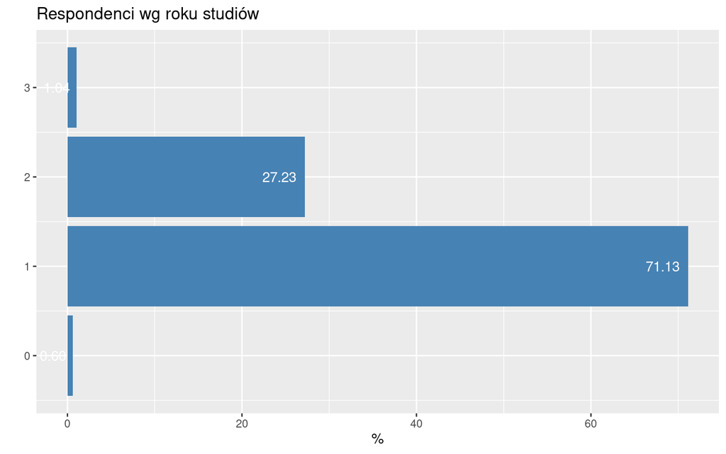

Deklarowana aktywność studenta w czasie studiów była ustalona w oparciu o jego odpowiedzi na pytania: **Brałem udział w programie Erasmus** oraz **Brałem udział w aktywności Samorządu Studenckiego/kół naukowych lub imprezach organizowanych przez Samorząd Studencki (juwenalia/otrzęsiny)** Aktywny to taki respondent, który chociaż na jedno pytanie udzielił odpowiedzi twierdzącej.

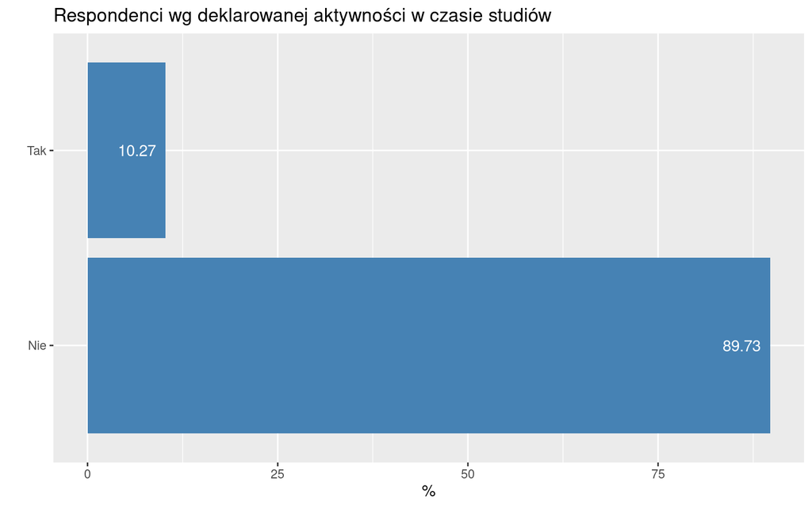

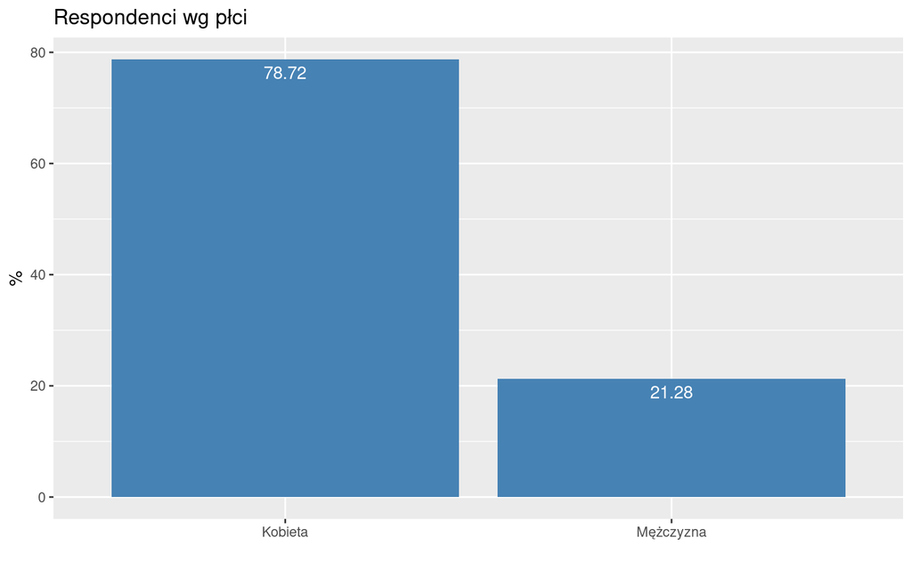

## Ocena PSW

Miarą oceny jest odsetek wskazań (pozytywnych/negatywnych/obojętnych)

### Oceny pozytywne

Miarą ocen pozytywnych jest odsetek wskazań **bardzo dobrze**

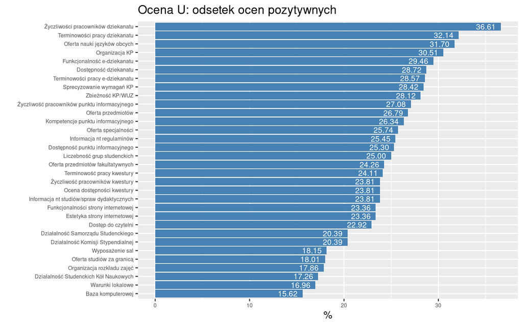

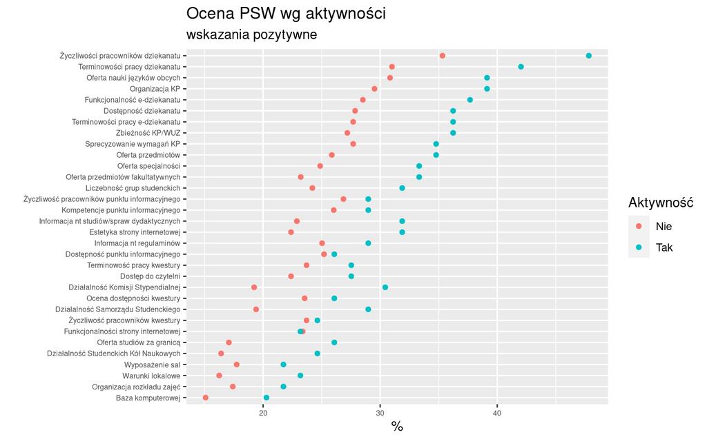

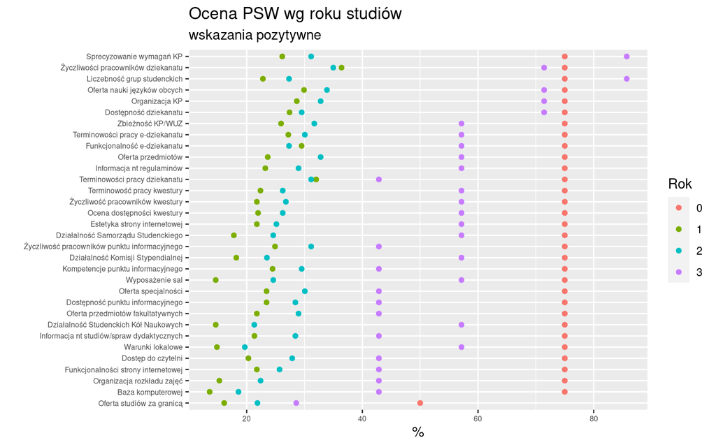

### Oceny negatywne

Miarą ocen negatywnych jest odsetek wskazań **Bardzo źle**/**Źle**

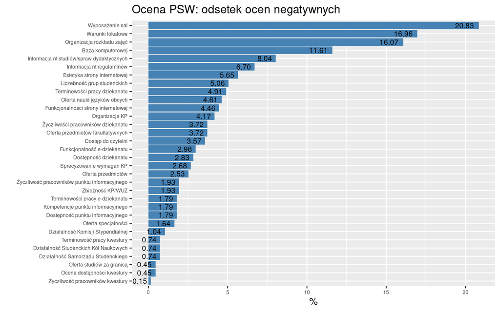

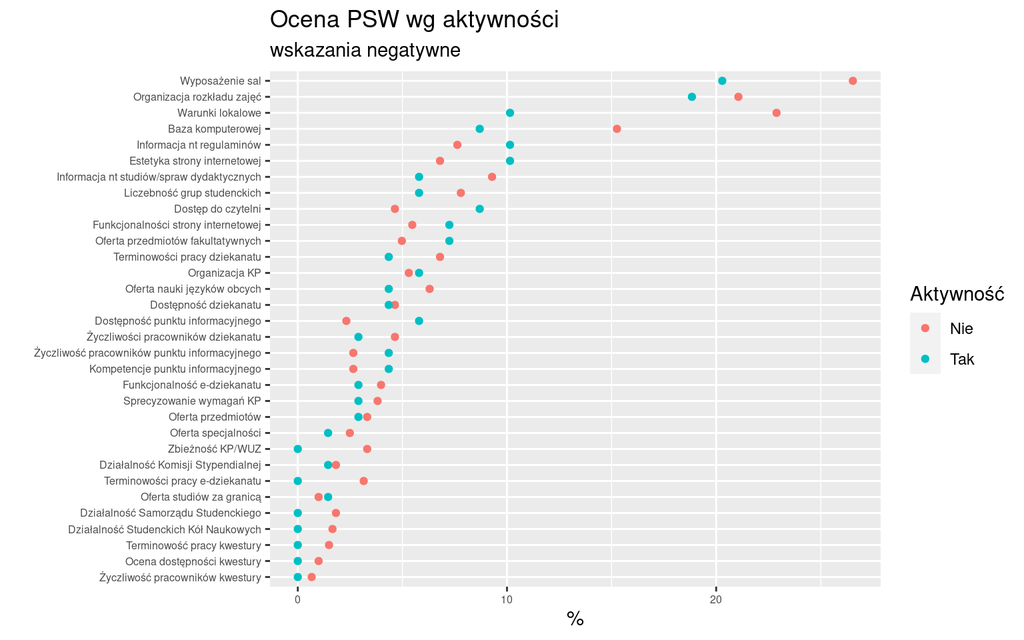

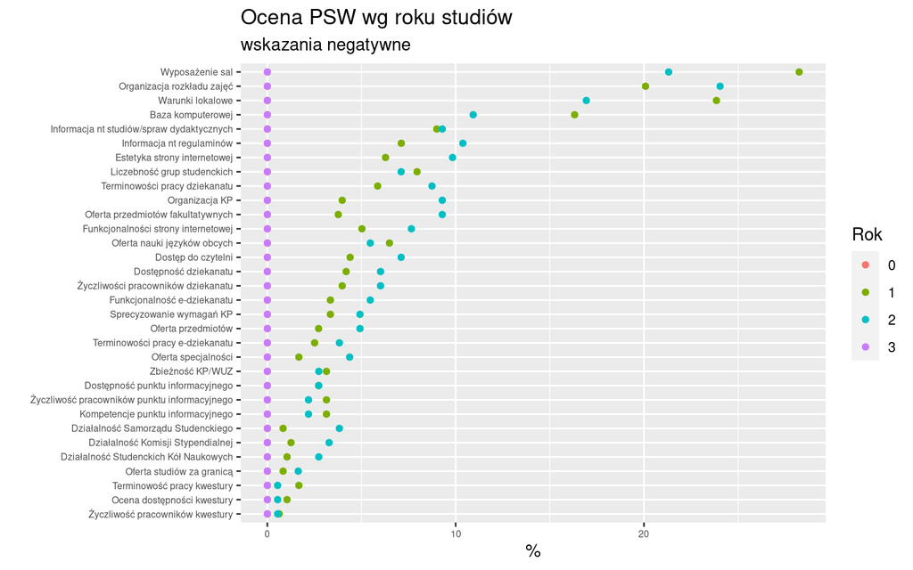

### Nie mam zdania

**Nie mam zdania/Nie wiem** może wskazywać na problem małego zaangażowania studentów w określonym obszarze.

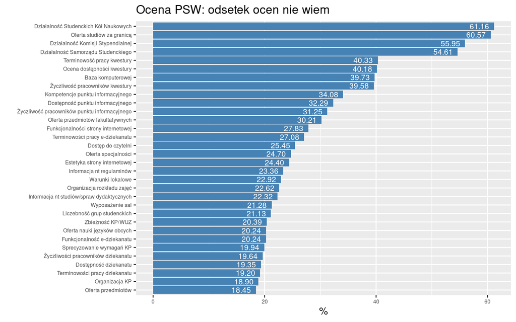

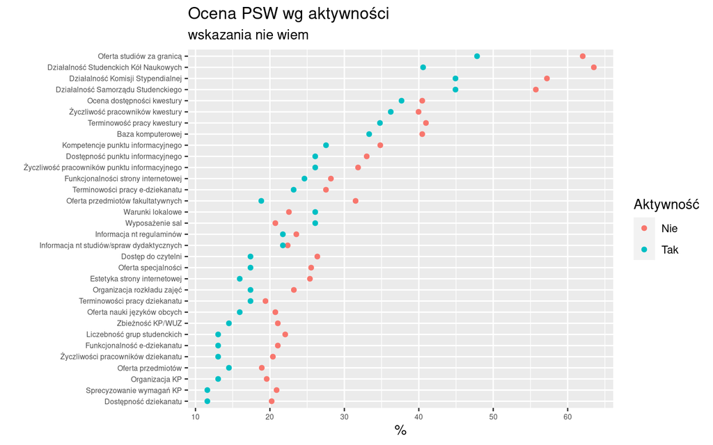

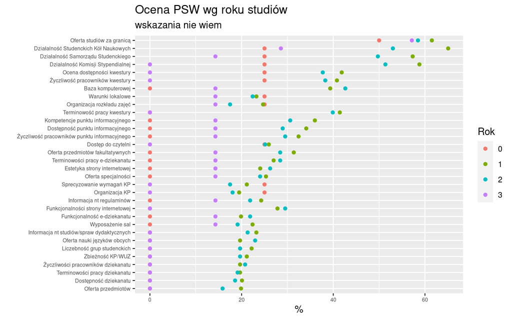

## Ankieta

| nr | skrót | pytanie |
| --- | --- | --- |
| p1 | Oferta przedmiotów | Jak Pan/Pani ocenia ofertę przedmiotów (zakres i treść) |
| p2 | Oferta specjalności | Jak Pan/Pani ocenia ofertę specjalności (zakres) |
| p3 | Oferta przedmiotów fakultatywnych | Jak Pan/Pani ocenia ofertę przedmiotów fakultatywnych (zakres i treść) |
| p4 | Informacja nt studiów/spraw dydaktycznych | Jak Pan/Pani ocenia dostępność i przejrzystości informacji dotyczących programów studiów i spraw dydaktycznych |
| p5 | Informacja nt regulaminów | Jak Pan/Pani ocenia dostępność informacji dotyczącej regulaminów (studiów, pomocy materialnej, innych), programów kształcenia, wymagań egzaminacyjnych oraz zasad pobierania opłat |
| p6 | Oferta nauki języków obcych | Jak Pan/Pani ocenia ofertę nauki języków obcych (zakres i stopień zaawansowania) |
| p7 | Oferta studiów za granicą | Jak Pan/Pani ocenia ofertę studiów za granicą wramach programu Erasmus |
| p8 | Warunki lokalowe | Jak Pan/Pani ocenia ogólne warunków lokalowe |
| p9 | Wyposażenie sal | Jak Pan/Pani ocenia wyposażenia sal wspomagających proces kształcenia (audiowizualne, tablice itp.) |
| p10 | Baza komputerowej | Jak Pan/Pani ocenia bazę komputerową |
| p11 | Liczebność grup studenckich | Jak Pan/Pani ocenia liczebności grup studenckich waktywnych formach zajęć (ćwiczenia/laboratoria) |
| p12 | Organizacja rozkładu zajęć | Jak Pan/Pani ocenia racjonalność i organizację rozkładu zajęć |
| p13 | Dostęp do czytelni | Jak Pan/Pani ocenia dostęp do wypożyczalni/czytelni idostępnych w niej zbiorów |
| p14 | Sprecyzowanie wymagań KP | Jak Pan/Pani ocenia sprecyzowanie wymagań dotyczących wykonywanych zadań i zaliczania umiejętności podczas kształcenia praktycznego |
| p15 | Organizacja KP | Jak Pan/Pani ocenia organizację kształcenia praktycznego (dobór placówek, kadry) |
| p16 | Zbieżność KP/WUZ | Jak Pan/Pani ocenia zbieżność czynności wykonywanych podczas kształcenia praktycznego zprogramem wymaganych umiejętności zawodowych |
| p17 | Dostępność dziekanatu | Jak Pan/Pani ocenia dostępność dziekanatu |
| p18 | Życzliwości pracowników dziekanatu | Jak Pan/Pani ocenia życzliwości/otwartość/chęć pomocy pracowników dziekanatu |
| p19 | Terminowości pracy dziekanatu | Jak Pan/Pani ocenia pracę dziekanatu pod względem terminowości załatwiania spraw/kompetencji |
| p20 | Funkcjonalność e-dziekanatu | Jak jest Pana/Pani ocenia funkcjonalność e-dziekanatu |
| p21 | Terminowości pracy e-dziekanatu | Jak Pan/Pani ocenia pracę e-dziekanatu pod względem terminowości załatwiania spraw |
| p22 | Czego brakuje/co by należałby usprawnić w pracy e-dziekanatu: | Proszę określić czego brakuje/co by należałby usprawnić w pracy e-dziekanatu: |
| p23 | Estetyka strony internetowej | Jak jest Pana/Pani ocena estetyki uczelnianej strony internetowej |
| p24 | Funkcjonalności strony internetowej | Jak jest Pana/Pani ocena funkcjonalności uczelnianej strony internetowej oraz aktualności/kompletności insformacji na tej stronie |
| p25 | Co by należało poprawić na uczelnianej stronie internetowej? | Proszę określić czego brakuje/co by należało poprawić na uczelnianej stronie internetowej: |
| p26 | Ocena dostępności kwestury | Jak Pan/Pani ocenia dostępność kwestury |
| p27 | Życzliwość pracowników kwestury | Jak Pan/Pani ocenia życzliwości/otwartość/chęć pomocy pracowników kwestury |
| p28 | Terminowość pracy kwestury | Jak Pan/Pani ocenia pracę kwestury pod względem terminowości załatwiania spraw/kompetencji |
| p29 | Dostępność punktu informacyjnego | Jak Pan/Pani ocenia dostępność punktu informacyjnego |
| p30 | Życzliwość pracowników punktu informacyjnego | Jak Pan/Pani ocenia życzliwości/otwartość/chęć pomocy pracowników punktu informacyjnego |
| p31 | Kompetencje punktu informacyjnego | Jak Pan/Pani ocenia pracę punktu informacyjnego pod względem kompetencji |
| p32 | Działalność Komisji Stypendialnej | Jak Pan/Pani ocenia działalność Uczelnianej Komisji Stypendialnej |
| p33 | Działalność Samorządu Studenckiego | Jak Pan/Pani ocenia działalność Samorządu Studenckiego |
| p34 | Działalność Studenckich Kół Naukowych | Jak Pan/Pani ocenia działalność Studenckich Kół Naukowych |
| p35 | Brałem udział w programie Erasmus | Brałem udział wprogramie Erasmus |
| p36 | Brałem udział w aktywności Studenckiej | Brałem udział w aktywności Samorządu Studenckiego/kół naukowych lub imprezach organizowanych przez Samorząd Studencki (juwenalia/otrzęsiny) |